# Practica4

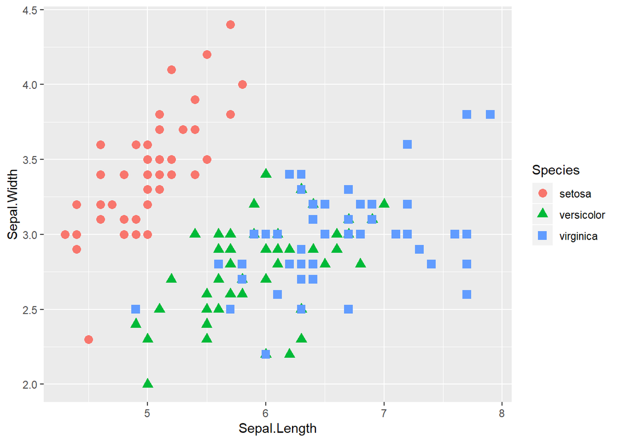

```r
ggplot(data=iris, aes(x=Sepal.Length, y= Sepal.Width)) +
    geom_point(aes(color= Species, shape=Species), size=3)
```

Si queremos quitar el fondo gris:

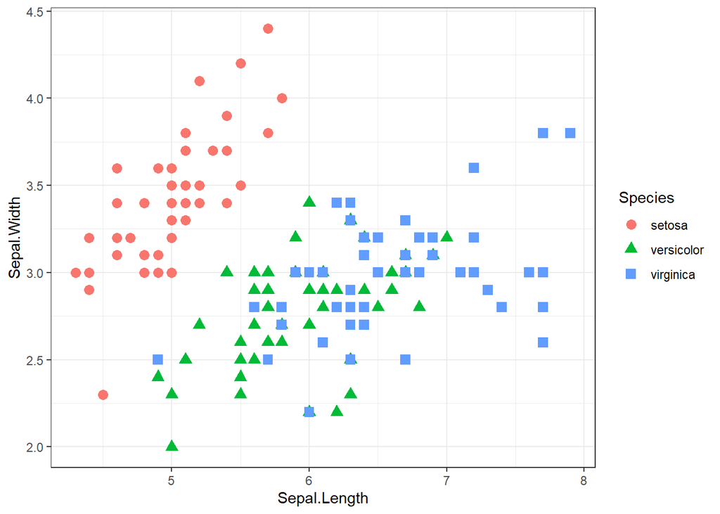

```r
ggplot(data=iris, aes(x=Sepal.Length, y= Sepal.Width)) +
    geom_point(aes(color= Species, shape=Species), size=3) +
    theme_bw()
```

A veces queremos graficar en páneles separados la misma info para diferentes tratamientos o especies. Por ejemplo:

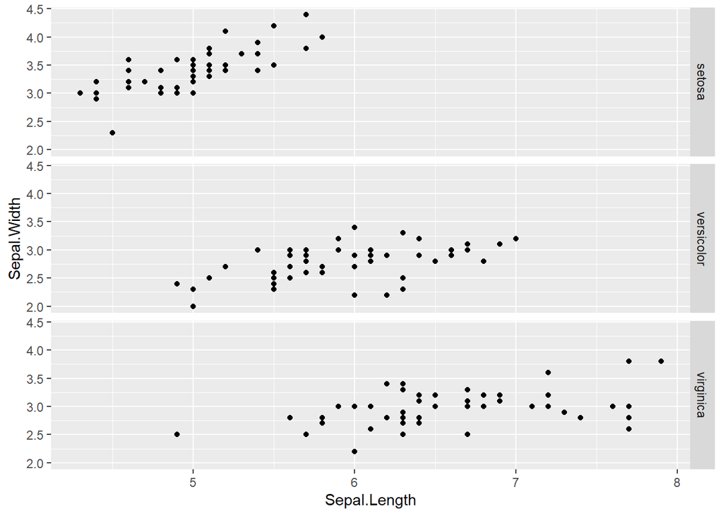

```r
ggplot(data=iris, aes(x=Sepal.Length, y= Sepal.Width)) +
  geom_point() +
  facet_grid(Species ~ .)
```

**Ejercicio** Pon color por especie a la gráfica anterior:

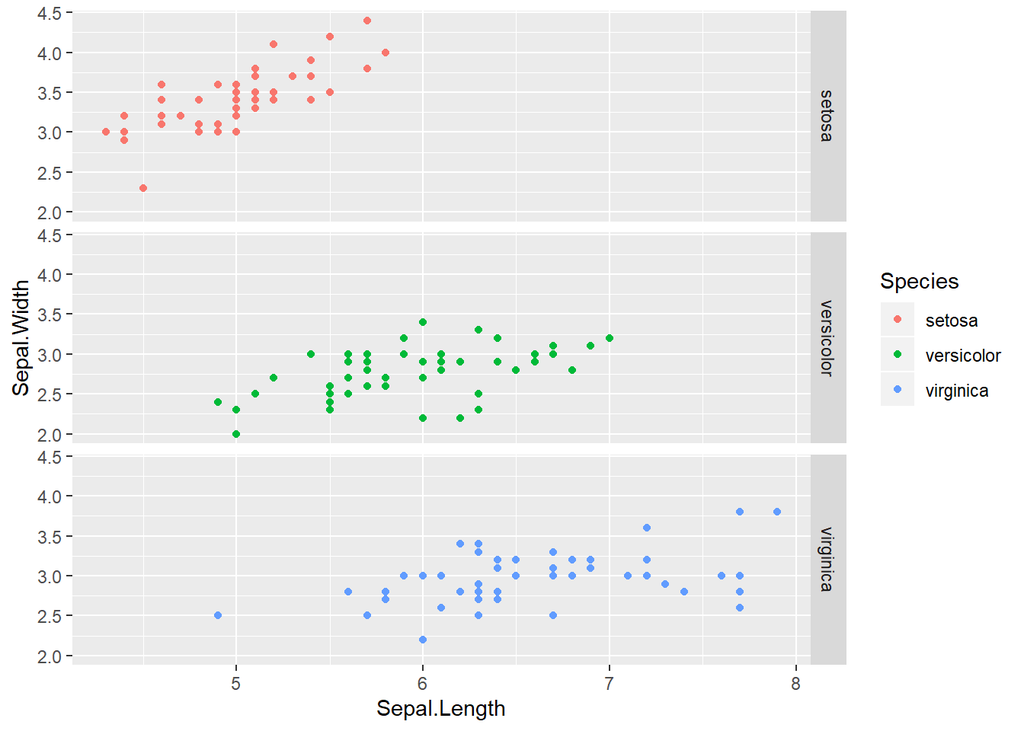

Repite la gráfica anterior pero para que se vea así:

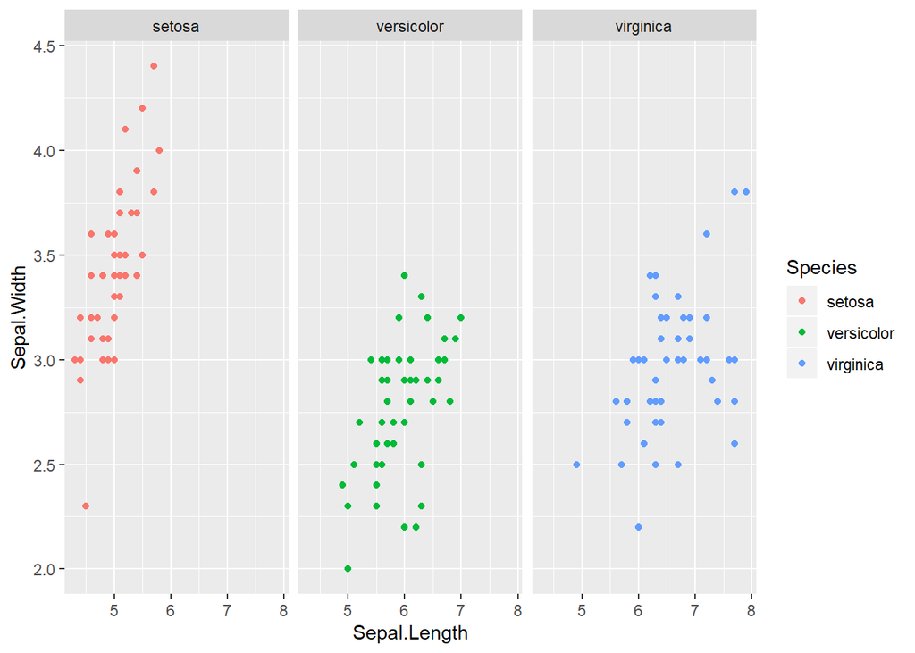

También podemos agregar el resultado de un modelo matemático, como una regresión lineal:

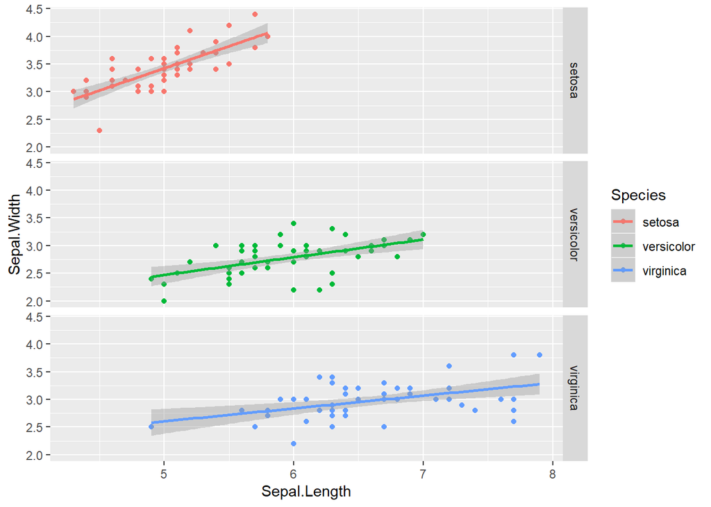

```r
ggplot(data=iris, aes(x=Sepal.Length, y= Sepal.Width, color=Species)) +
  geom_point() +
  facet_grid(Species ~ .) +
  geom_smooth(method="lm")
```

En `ggplot2` se construye la gráfica agregando diferentes capas o *layers*, diferentes tipos de capas que se trataran en este curso son:

1. **Aesthetic**: `aes()` propiedades de objetos por mapear en la gráfica (axis x, axis y, size, shape, color, fill).
2. **Geoms**: `geom_` Objetos geométricos. Estos objetos se dividen en objetos que mapean en una dimensión, dos dimensiones y tres dimensiones.
3. **Transformaciones estadísticas**: `stat_` Resúmen estadístico de variables.
4. **Facets**: `facet_` División de gráficas en diferentes paneles o subgráficas.
5. **Themes**: `theme()` Aspectos de la gráfica independientes de los datos, como: fuente, títulos, posición de leyendas y fondo.

Existen dos funciones para graficar: `ggplot` y `qplot`.

1. Gráficas de dispersión

Usaremos el conjunto de datos *mpg* que se incluye en R, puedes encontrar información de esta base de datos tecleando `?mpg`.

```r
# estructura de la base
str(mpg)
```

```
## Classes 'tbl_df', 'tbl' and 'data.frame':    234 obs. of  11 variables:
##  $ manufacturer: chr  "audi" "audi" "audi" "audi" ...
##  $ model       : chr  "a4" "a4" "a4" "a4" ...
##  $ displ       : num  1.8 1.8 2 2 2.8 2.8 3.1 1.8 1.8 2 ...
##  $ year        : int  1999 1999 2008 2008 1999 1999 2008 1999 1999 2008 ...
##  $ cyl         : int  4 4 4 4 6 6 6 4 4 4 ...
##  $ trans       : chr  "auto(l5)" "manual(m5)" "manual(m6)" "auto(av)" ...
##  $ drv         : chr  "f" "f" "f" "f" ...
##  $ cty         : int  18 21 20 21 16 18 18 18 16 20 ...
##  $ hwy         : int  29 29 31 30 26 26 27 26 25 28 ...
##  $ fl          : chr  "p" "p" "p" "p" ...
##  $ class       : chr  "compact" "compact" "compact" "compact" ...
```

Para realizar una gráfica de dispersión:

1. Se debe especificar explícitamente que base de datos usamos, este es el primer argumento en la función `ggplot`
2. Dentro de *aes()* escribimos la variable que queremos graficar en cada eje.
3. Posteriormente se definen las geometrías, *geoms*, que controlan el tipo de gráfica. Así se agrega otra capa a la gráfica con el símbolo `(+)`.

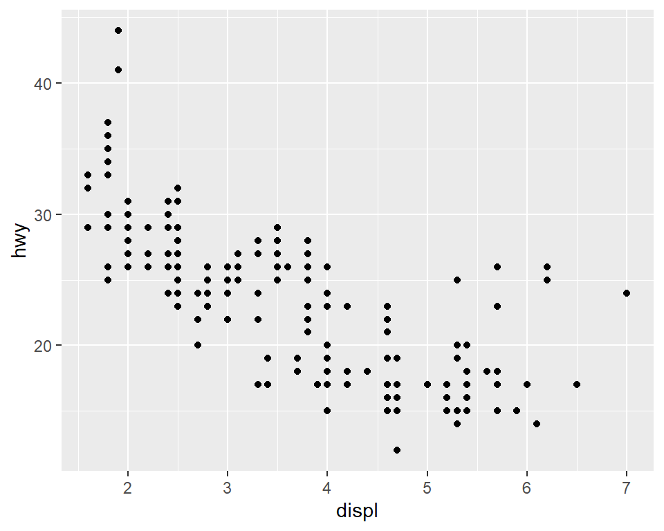

```r
ggplot(mpg, aes(x = displ, y = hwy)) +
  geom_point()
```

La forma paralela de graficar con `qplot` se presenta abajo.

```r
qplot(displ, hwy, data = mpg, geom = 'point')
```

Podemos representar variables adicionales usando otras características estéticas (*aesthetics*) como forma, color o tamaño.

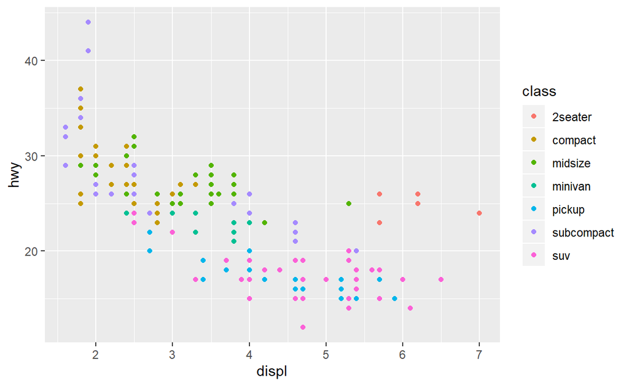

```r
ggplot(mpg, aes(x = displ, y = hwy, color = class)) +
  geom_point()
```

La forma paralela de graficar con `qplot` se presenta abajo.

```r
qplot(displ, hwy, color = class, data = mpg, geom = 'point')
```

Ahora se prueba con otras variables estéticas.

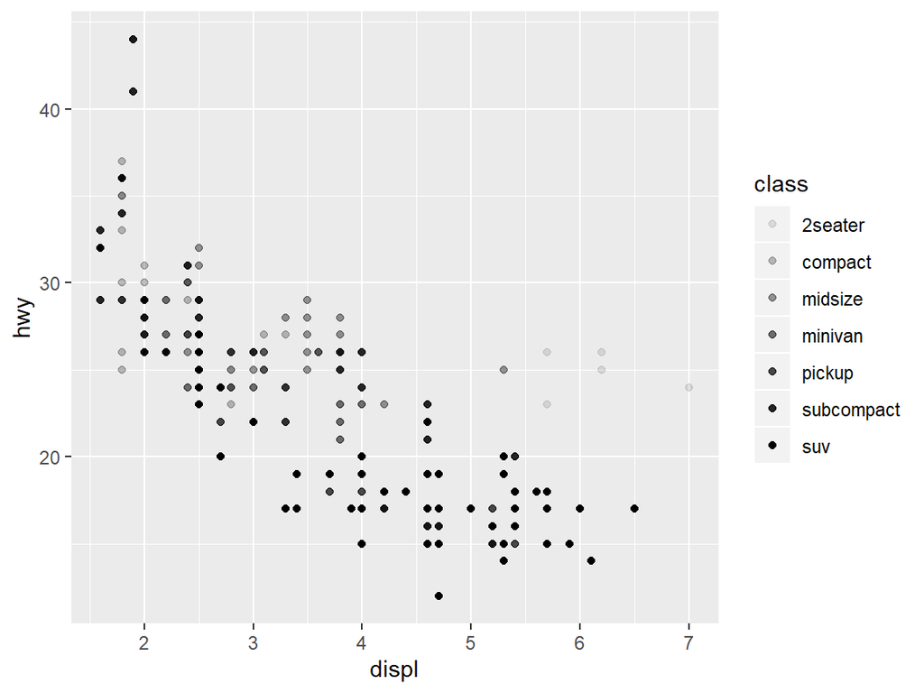

```r
ggplot(data = mpg) +
  geom_point(mapping = aes(x = displ, y = hwy, alpha = class))
```

Agregando valores estéticos podemos graficar hasta 5 variables en una sola gráfica.

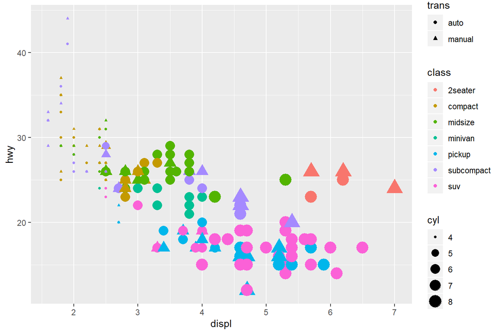

```r
mpg$trans <- str_replace( str_extract( mpg$trans, pattern = ".*[(]"), "[(]", "")
ggplot(mpg, aes(x = displ, y = hwy,
                color = class, shape = trans,
                size = cyl)) +
  geom_point()
```

***Tipos de variables

El mapeo de las propiedades estéticas depende del tipo de variable, las variables discretas se mapean a distintas escalas que las variables continuas:

|  | Discreta | Continua |
| --- | --- | --- |
| Color | Arcoiris de colores | Gradiente de colores |
| Tamaño | Escala discreta de tamaños | Mapeo lineal entre el radio y el valor |
| Forma | Distintas formas | No aplica |

En la siguiente gráfica se muestra la variable categórica *class* reordenada en el eje x.

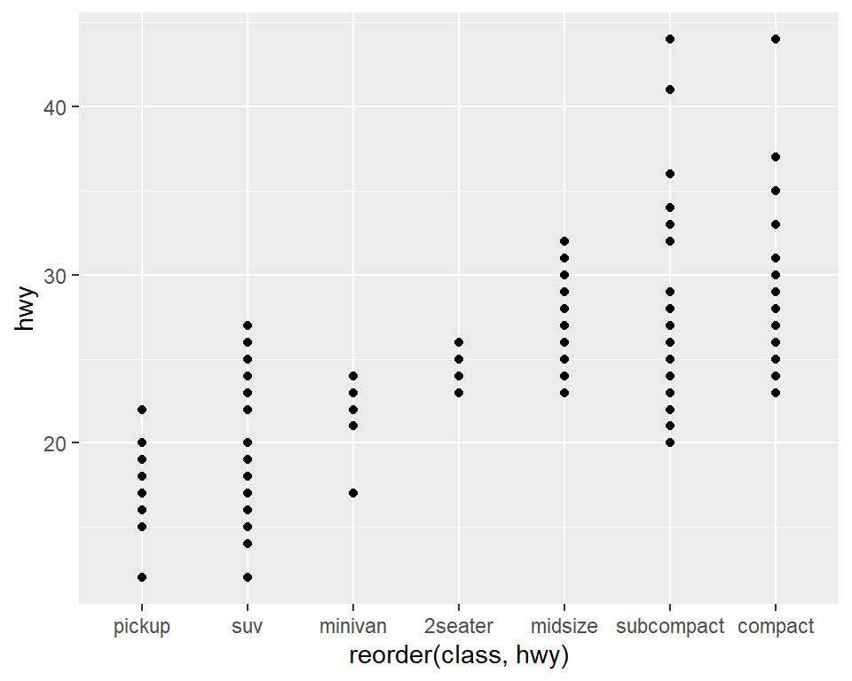

```r
ggplot(mpg, aes(x = reorder(class, hwy), y = hwy)) +
    geom_point()
```

El problema con la gráfica es que no es muy informativa, por que no se observa variabilidad de los puntos. Una forma de corregirla es agregando *vibraciones* o *jitter*.

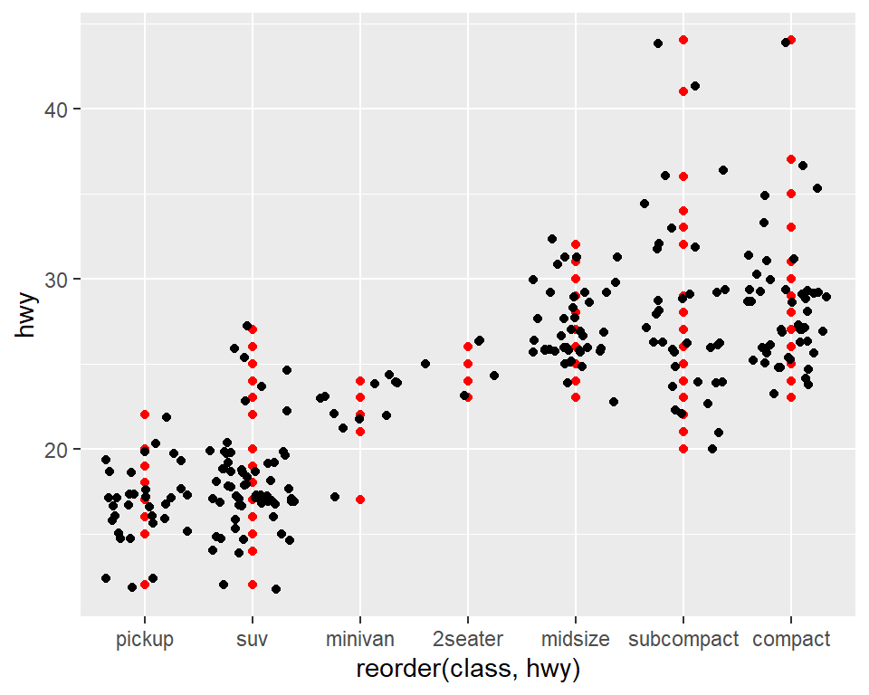

```r
ggplot(mpg, aes(x = reorder(class, hwy), y = hwy)) +
  geom_point(color = 'red') +
  geom_jitter()
```

Se mencionó previamente que es posible graficar resúmenes estadísticos. En este ejemplo, agregaremos una capa más con un objeto `boxplot`.

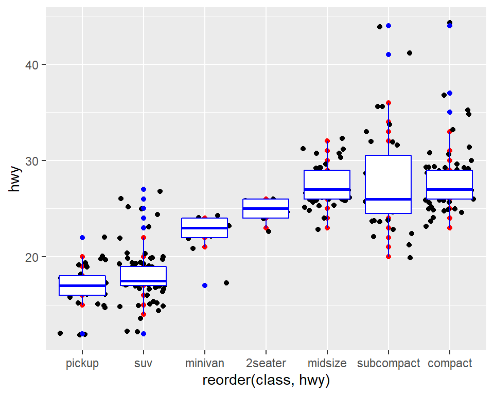

```r
ggplot(mpg, aes(x = reorder(class, hwy), y = hwy)) +
  geom_point(color = 'red') +
  geom_jitter() +
  geom_boxplot(color = 'blue')
```

Nota que cada objeto de cada capa que se agrega tiene asignado un color diferente.

Modificar elementos

La gráfica tiene diferentes elementos, como: texto de los ejes, títulos de los ejes, títulos de las gráficas, leyendas de estéticas, etc. Una forma de modificar el tamaño, color, posición o rotación es mediante la función `theme()` y `element_text()`.

Por ejemplo, de la base **mpg** queremos observar el rendimiento de millas por galón en carretera **hwy** por cada fabricante **manufacturer**.

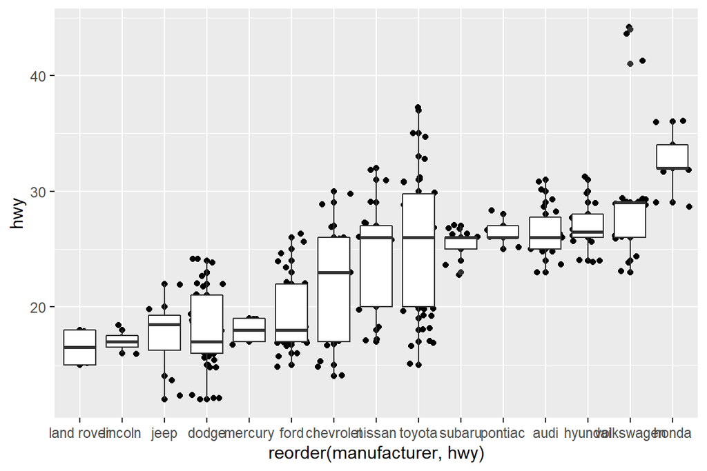

```r
ggplot(mpg, aes(x = reorder(manufacturer, hwy), y = hwy)) +
  geom_point() +
  geom_jitter() +
  geom_boxplot()
```

El problema con la gráfica anterior es la dificultad para leer los fabricante, por lo que se hace una rotación del texto del eje x.

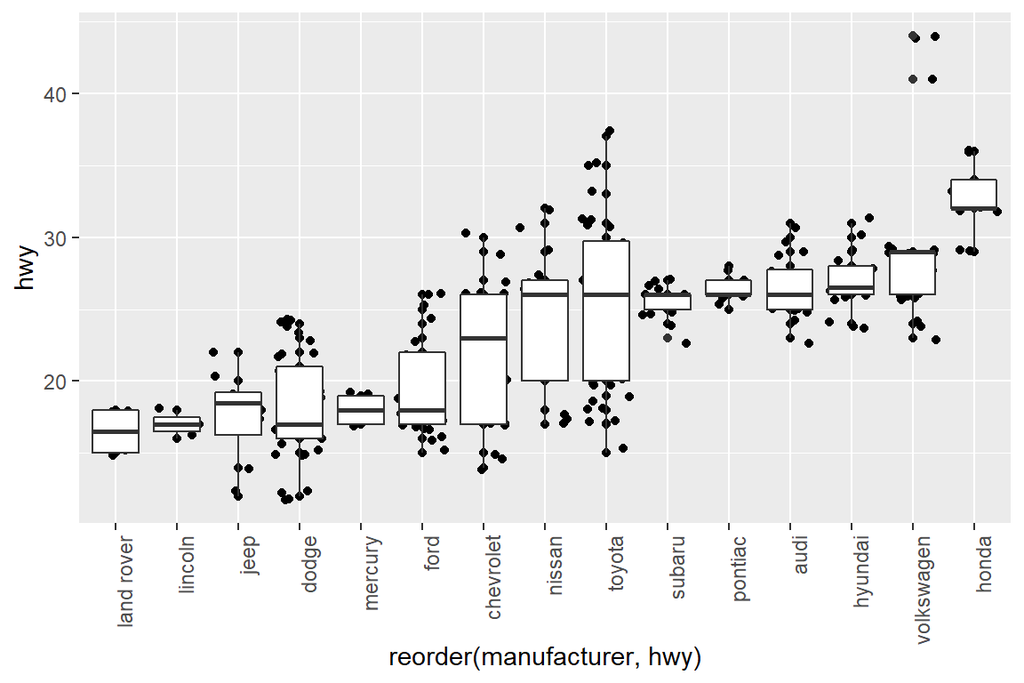

```r
ggplot(mpg, aes(x = reorder(manufacturer, hwy), y = hwy)) +
  geom_point() +
  geom_jitter() +
  geom_boxplot() +
  theme(axis.text.x = element_text(angle = 90, hjust = 1))
```

Dentro de cada **geom** es posible cambiar distintas características. Por ejemplo, el color y tamaño de cada punto de la gráfica de dispersión.

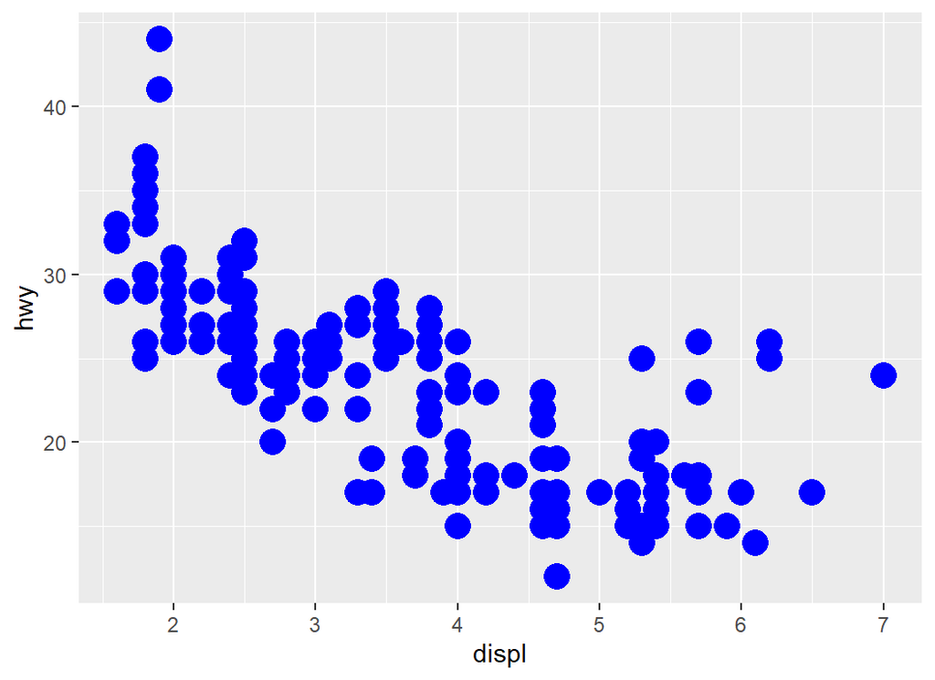

```r
ggplot(data = mpg) +
  geom_point(mapping = aes(x = displ, y = hwy), color = "blue", size = 5)
```

¿Por qué la siguiente gráfica no imprime los puntos en color azul?

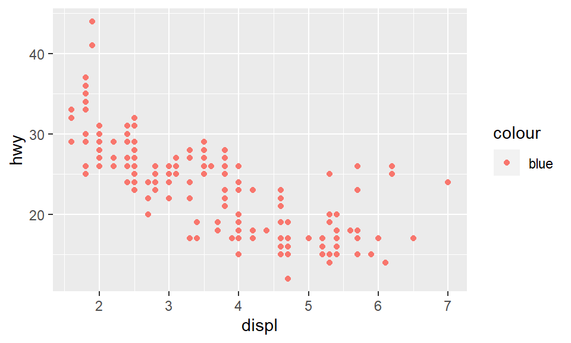

```r
ggplot(data = mpg) +
  geom_point(aes(x = displ, y = hwy, color = "blue"))
```

¿Qué sucede si en la siguiente gráfica agregas `legend.position = "none"` o `legend.position = "bottom"`.

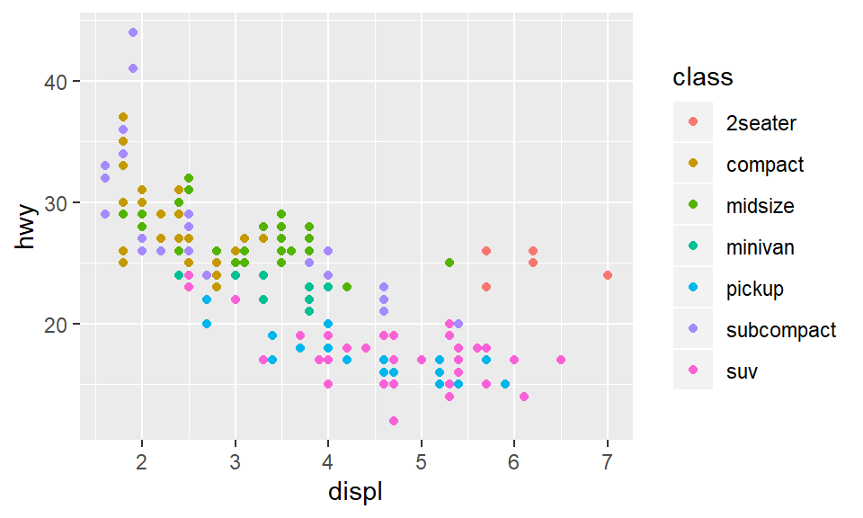

```r
ggplot(mpg, aes(displ, hwy)) +
  geom_point(aes(colour = class)) +
  theme()
```

¿Qué sucede si en el objeto geométrico de los puntos incluyes `show.legend = F`? No añade etiquetas

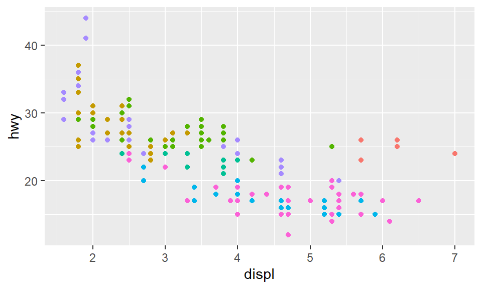

```r
ggplot(mpg, aes(displ, hwy)) +
  geom_point(aes(colour = class),show.legend = F) +
  theme()
```

```r
#getwd()
setwd("C:/Users/dor3l/Documents/Escuela/ITAM/CienciaDeDatos/Propedeutico/R_intro-master/R_intro-master/2_visualizacion/data/")
# 1.
conapo <- read_csv('conapo.csv')
# 2.
str(conapo)
# 5.
tab.df <- conapo[conapo$CVE_ENT == '09', ]
ggplot(tab.df,
       aes(x = salarios_minimos, y = sin_electricidad)) +
  geom_point( aes( color = analfabeta), size = 5) +
  geom_text(aes(label = NOM_MUN), check_overlap = T)
# 6.
ggplot(conapo, aes(x = reorder(NOM_ENT, analfabeta, median),
                   y = analfabeta)) +
  geom_point(size = .3) +
  geom_jitter(size = .2) +
  theme(axis.text.x = element_text(angle = 90, hjust = 1))
# 7.
ggplot(conapo, aes(x = reorder(NOM_ENT, analfabeta, median),
                   y = analfabeta)) +
  geom_boxplot() +
  geom_jitter(alpha = .2, size = .3) +
  theme(axis.text.x = element_text(angle = 90, hjust = 1)) +
  ylab('Proporción de población analfabeta\nen el muncipio')+
  xlab('Entidad Federativa')
```

2. Gráficas de panel

El objetivo de las gráficas de panel es hacer varios múltiplos de una gráfica, donde cada múltiplo representa un subconjunto de los datos. Es una práctica muy útil para explorar relaciones condicionales.

En ggplot una forma es usar la función `facet_wrap()` para hacer paneles dividiendo los datos de acuerdo a las categorías de una sola variable.

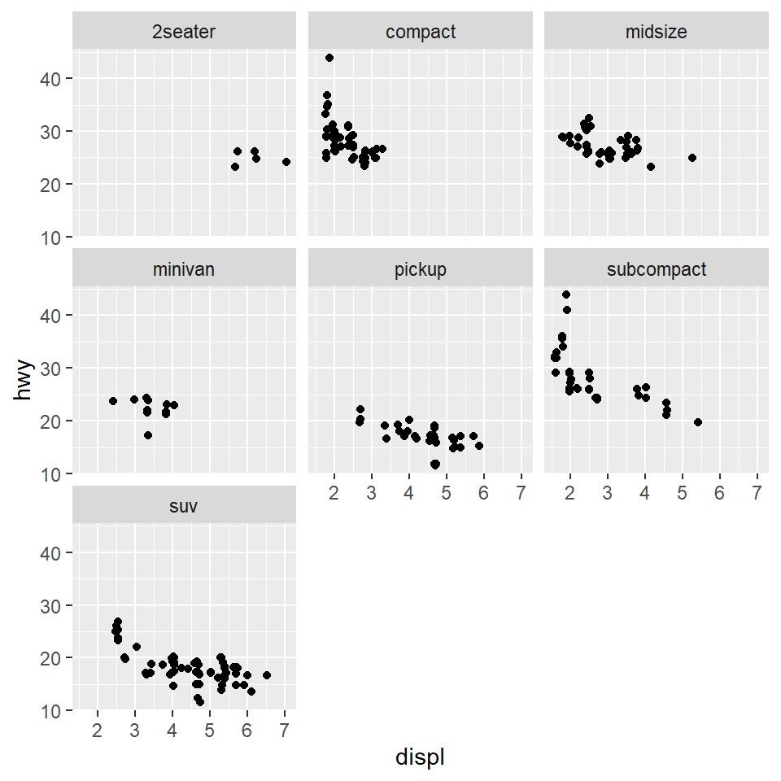

```r
ggplot(mpg, aes(x = displ, y = hwy)) +
  geom_jitter() +
  facet_wrap(~ class)
```

También podemos hacer una cuadrícula de 2 dimensiones usando `facet_grid(filas~columnas)`

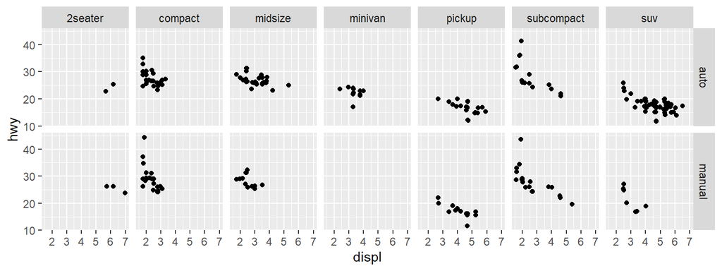

```r
ggplot(mpg, aes(x = displ, y = hwy)) +
  geom_jitter() +
  facet_grid(trans~ class)
```

`Ejercicio`:

1. Recrea la siguiente gráfica. ¿Hay algún problema si la variable con la que generas los paneles es numérica?

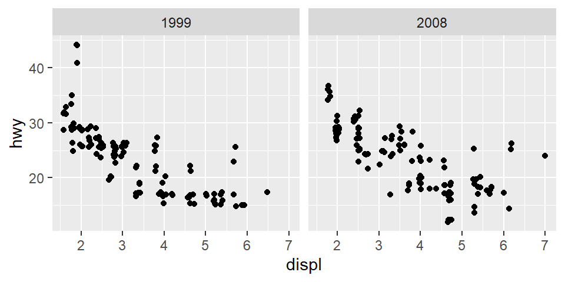

2. ¿Qué gráfica se obtiene del siguientes código? ¿Qué hace `.`?

```r
ggplot(mpg, aes(x = displ, y = hwy)) +
  geom_jitter() +
  facet_grid(.~ class)
```

3. ¿Qué sucede si en el objeto de panel `facet_wrap()` de la siguiente gráfica agregas `scales = 'free_y'` y `nrow = 1`?

```r
ggplot(mpg, aes(x = displ, y = hwy)) +
  geom_jitter() +
  facet_wrap(~ class,scales = 'free_y',nrow = 1)
```

4. Lee los datos ‘ingresos.csv’. Crea una variable con valor `TRUE` para los salarios que esten por arriba de la mediana y `FALSE` para los que no.
5. Grafica el género ordenado por la mediana de ingreso contra el ingreso y divide la gráfica por la variable binaria que creaste en el inciso 4.
6. Crea una variable de cortes de edad: menores o igual 35 años y mayores o igual a 35 años. (Tip: Usa la función `cut()`. Vale la pena revisar las funciones `cut_interval()` o `cut_number()`)
7. Repite la gráfica del inciso 5. pero ahora divide la gráfica por los rangos de edad que acabas de crear. `Respuesta`:

```r
setwd("C:/Users/dor3l/Documents/Escuela/ITAM/CienciaDeDatos/Propedeutico/R_intro-master/R_intro-master/2_visualizacion/")
# 1.
ggplot(mpg, aes(x = displ, y = hwy)) +
  geom_jitter() +
  facet_wrap(~ year)
# 4.
ingresos <- read_csv("data/ingresos.csv")
ingresos$ingreso_med <- ingresos$ingreso > median(ingresos$ingreso)
# 5.
ggplot(ingresos,
       aes(x = reorder(genero, ingreso, median),
           y = ingreso)) +
  geom_point() +
  geom_jitter() +
  geom_boxplot()+
  facet_wrap(~ingreso_med) +
  xlab('Género') +
  ylab('Ingreso')
# 6.
ingresos$edad.cut <- cut(ingresos$edad, breaks = c(0,35,60))
# 7.
ggplot(ingresos,
       aes(x = reorder(genero, ingreso, median), y = ingreso)) +
  geom_point() +
  geom_jitter() +
  geom_boxplot()+
  facet_wrap(~edad.cut)+
  xlab('Género') +
  ylab('Ingreso')
```

Otras Gráficas

***Suavizamientos

Al agregar suavizamientos se ajusta un modelo a los datos y en la grafica se imprimen las predicciones del modelo. La forma en que se agregan es con el objeto geométrico `geom_smooth()`.

En la siguiente gráfica para entender con mayor facilidad la gráfica de dispersión entre radiación solar y ozono se crea una nueva variable de la velocidad del viento y se agrega un suavizador (loess) por panel.

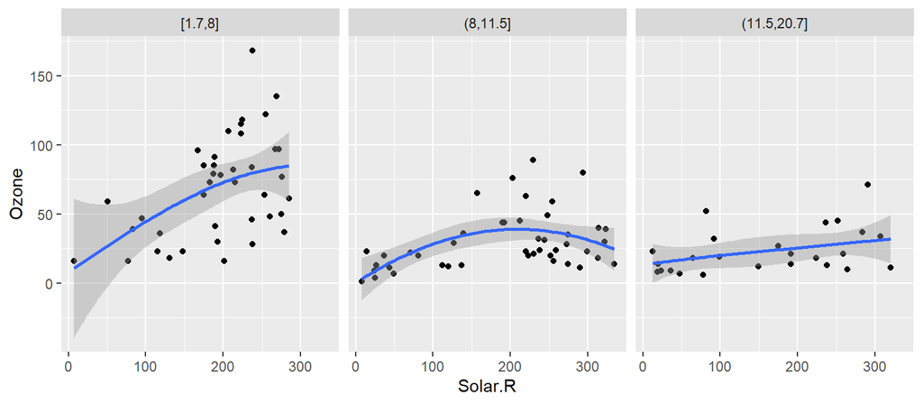

```r
data(airquality)
airquality$Wind.cat <- cut_number(airquality$Wind, 3)
ggplot(airquality, aes(x = Solar.R, y = Ozone)) +
  geom_point() +
  facet_wrap(~ Wind.cat) +
  geom_smooth(span = 3)
```

***Series

En ocasiones se desea ver en alguna secuencia las variables. Supongamos que queremos ver la tendencia de los nombres *John*, *Michael*, *Joshua* y *Christopher* para niños. Para ello se genera un subconjunto de la base de datos.

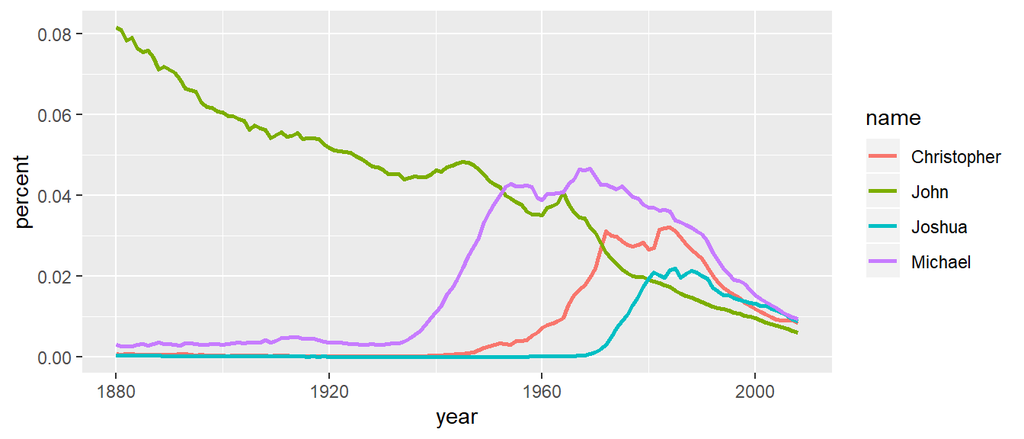

```r
setwd("C:/Users/dor3l/Documents/Escuela/ITAM/CienciaDeDatos/Propedeutico/R_intro-master/R_intro-master/2_visualizacion/")
bnames <- read_csv('data/bnames2.csv')
bnames$sex <- factor(bnames$sex, levels = 1:2, labels = c('boy', 'girl'))
sub.bnames <- bnames[bnames$name %in%
                       c("John", "Michael", "Joshua", "Christopher") &
                       bnames$sex == 'boy',]
ggplot(sub.bnames, aes(x = year, y = percent,
                       color = name, group = name)) +
  geom_line(size = 1)
```

***Barras

Las gráficas de barras se generan con el objeto `geom_bar()`. Este es uno de los objetos que hacen transformaciones estadísticas, en este caso en particular conteos.

En la siguiente gráfica se muestra el conteo de diamantes por cada calidad de corte **cut**.

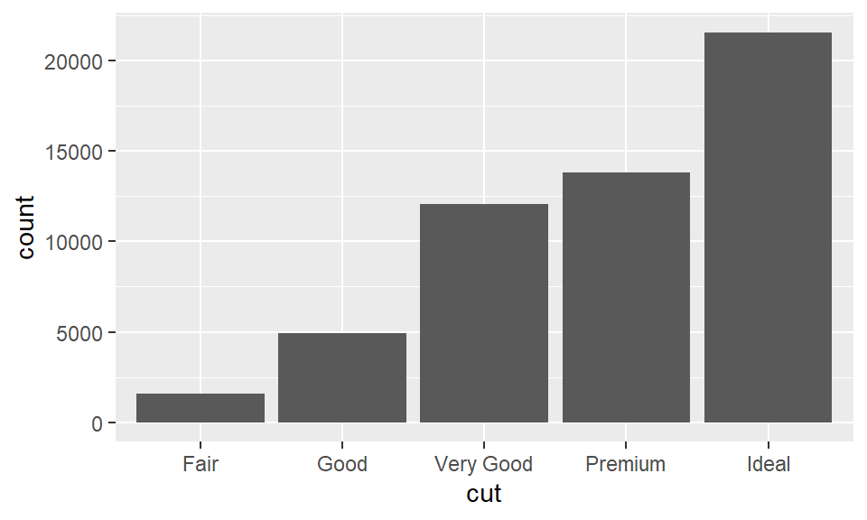

```r
ggplot(data = diamonds,
       aes(x = cut)) +
  geom_bar()
```

Es posible cambiar el valor estadístico de conteos, que es el estadístico default, a los conteos proporcionales con la especificación entre `..prop..` como se muestra abajo. Observar el eje y.

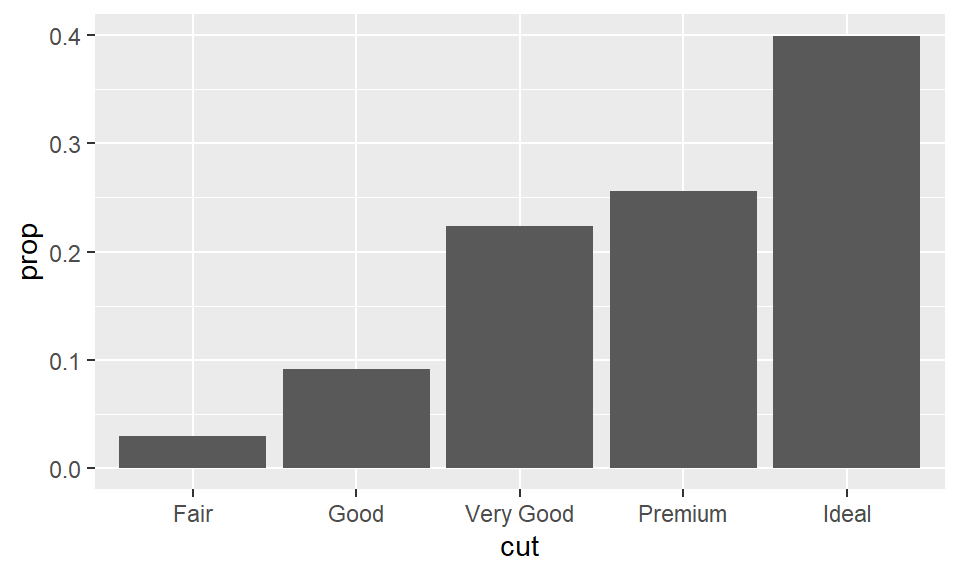

```r
ggplot(data = diamonds,
       aes(x = cut, y = ..prop.., group = 1)) +
  geom_bar()
```

Ahora, también es posible obtener la distribución proporcional de cada medida de claridad del diamante por corte **cut**.

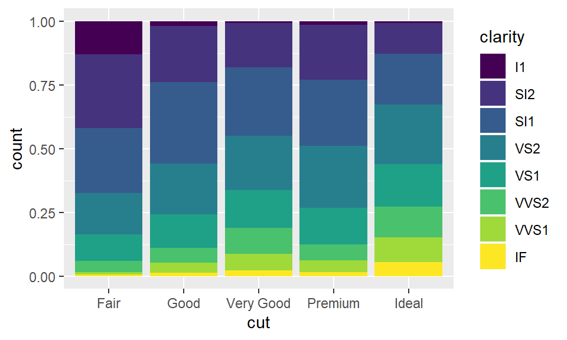

```r
ggplot(data = diamonds,
       aes(x = cut, fill = clarity)) +
  geom_bar( position = "fill")
```

***Histogramas

Los histogramas muestran la distribución de una variable numérica. El objeto geométrico para crear histogramas es `geom_histogram()`. La forma en que funciona este objeto es cortando la variable y cuenta el número de observaciones en cada corte. La forma de controlar el ancho de los cortes es con el argumento `binwidth`, es recomendable jugar con diferentes anchos de corte.

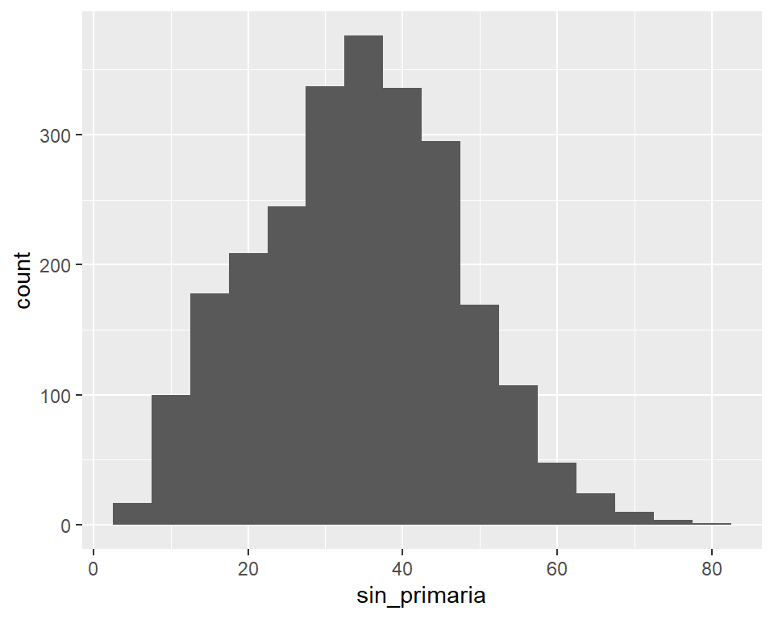

```r
setwd("C:/Users/dor3l/Documents/Escuela/ITAM/CienciaDeDatos/Propedeutico/R_intro-master/R_intro-master/2_visualizacion/")
conapo <- read_csv('data/conapo.csv')
ggplot(data = conapo, aes( x= sin_primaria)) +
  geom_histogram(binwidth =  5)
```

También se pueden sobre poner distintas distribución dependiendo de variables categóricos.

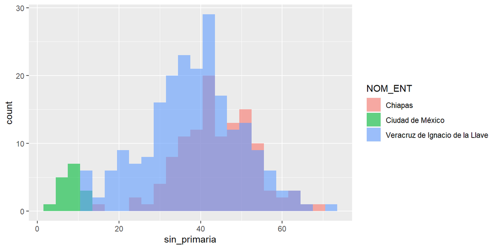

```r
sub <- conapo[conapo$CVE_ENT %in% c("09", "07", "30"),]
ggplot(data = sub, aes( x= sin_primaria, fill = NOM_ENT)) +
  geom_histogram(alpha = .6,
                 position = 'identity',
                 binwidth = 3)
```

**Nota:** También se recomiendan los objetos `geom_density()` y `geom_freqpoly()` muestran distribuciones de variables.

***Información estadística

Los siguientes objetos resumen información estadística con distintas transformaciones. Es por esto que no son objetos geométricos, son objetos estadísticos y se llaman como `stat_`:

- **QQ-Plot:** `stat_qq` Realiza una gráfica cuantil-cuantil de una muestra y la distribución teórica. Por default compara los cuantiles teóricos de la distribución normal.

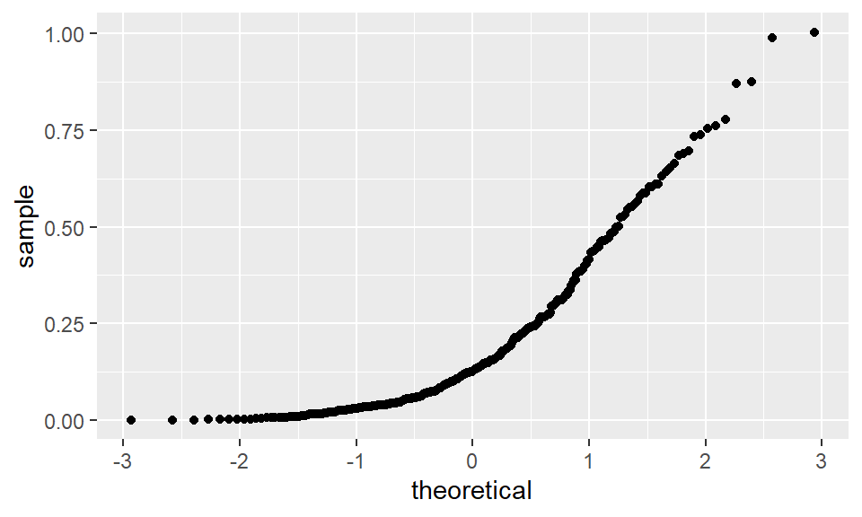

```r
tab <-  data.frame(
  simulación = rexp(300, rate = 5)
)
ggplot(tab, aes(sample = simulación)) +
      stat_qq()
```

En el siguiente ejemplo se modifica para comparar con los cuantiles teóricos de la distribución exponencial.

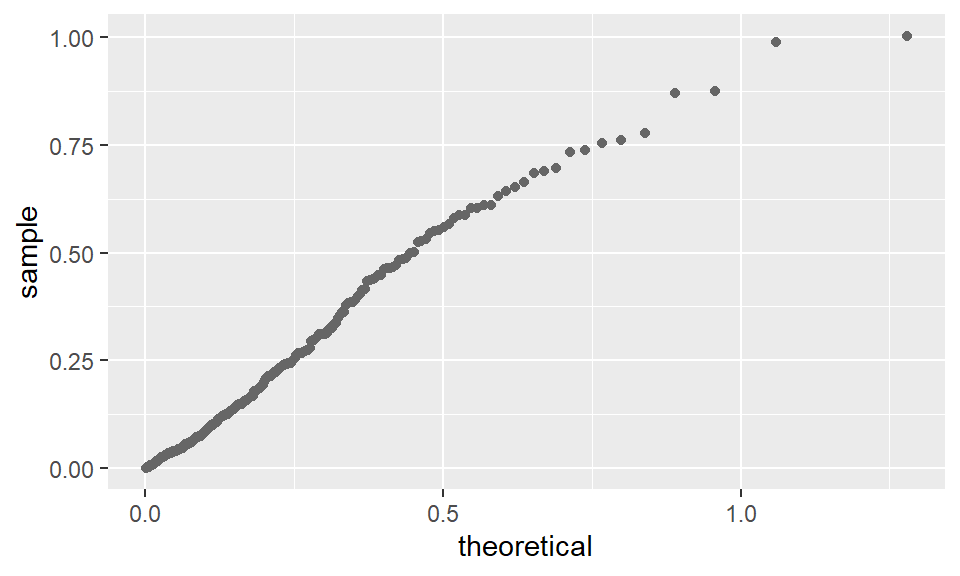

```r
ggplot(tab, aes(sample = simulación)) +
      stat_qq(distribution = qexp, dparams = 5,
              color = 'gray40')
```

En la siguiente gráfica se compara la distribución de simulaciones normales con distintos parámetros.

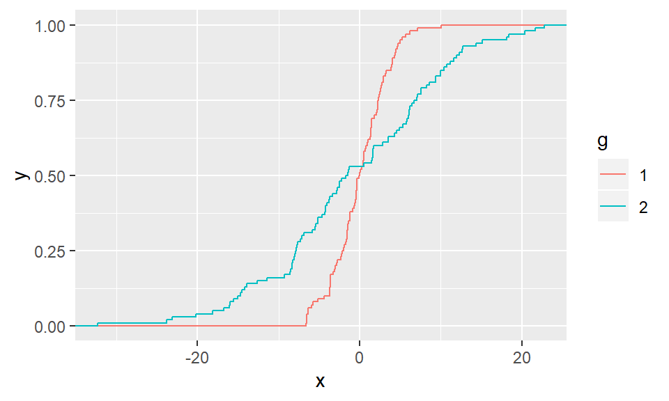

```r
df <- data.frame(x = c(rnorm(100, 0, 3),
                     rnorm(100, 0, 10)
                     ),
                 g = gl(2, 100))
ggplot(df, aes(x, colour = g)) +
  stat_ecdf()
```

***Funciones

Este objeto permite graficar funciones en un rango determinado. El objeto estadístico es `stat_function()` que tiene como argumento una función.

La siguiente gráfica muestra una función predeterminada del objeto estadístico `dnorm`, que es la distribución normal con media 2 y desviación 0.5.

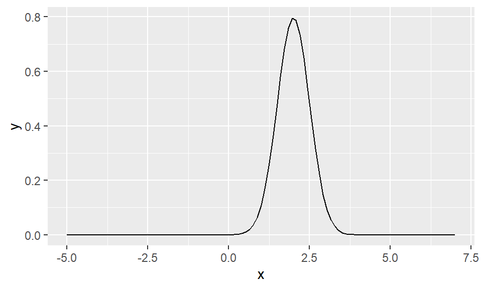

```r
ggplot(data.frame(x = c(-5, 7)), aes(x)) +
  stat_function(fun = dnorm, args = list(mean = 2, sd = .5))
```

También es posible gráficar cualquier función, como en el siguiente ejemplo:

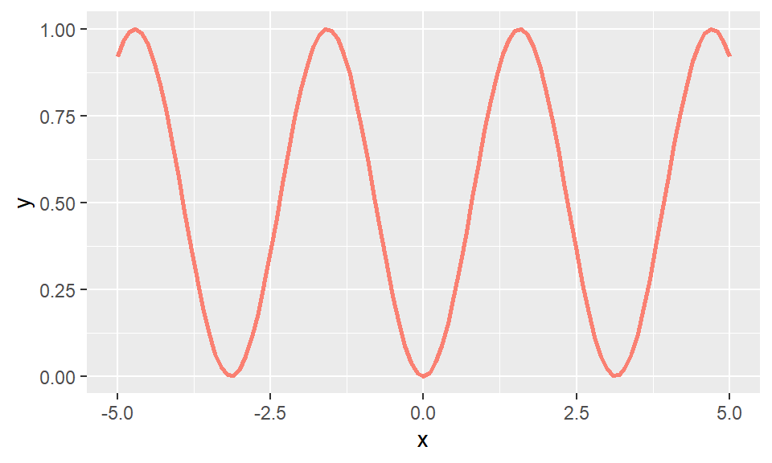

```r
FunSin <- function(x){
  sin(x)^2
}
ggplot(data.frame(x = c(-5, 5)), aes(x)) +
  stat_function(fun = FunSin, size = 1, color = 'salmon')
```